# Red Wine Quality Exploratory Anlysis by Meaad AlRshoud

# Load all of the packages

```
## [1] "Dataset Attributes"
```

```
##
## * fixed.acidity
## * volatile.acidity
## * citric.acid
## * residual.sugar
## * chlorides
## * free.sulfur.dioxide
## * total.sulfur.dioxide
## * density
## * pH
## * sulphates
## * alcohol
## * quality
##
## <!-- end of list -->
```

# Univariate Plots Section

```
##
## -------------------------------------------------------------------
##  fixed.acidity   volatile.acidity    citric.acid    residual.sugar
## --------------- ------------------ --------------- ----------------
##  Min.  : 4.60     Min.  :0.1200     Min.  :0.000    Min.  : 0.900
##
##  1st Qu.: 7.10    1st Qu.:0.3900    1st Qu.:0.090   1st Qu.: 1.900
##
##  Median : 7.90    Median :0.5200    Median :0.260   Median : 2.200
##
##   Mean : 8.32      Mean :0.5278      Mean :0.271     Mean : 2.539
##
##  3rd Qu.: 9.20    3rd Qu.:0.6400    3rd Qu.:0.420   3rd Qu.: 2.600
##
##  Max.  :15.90     Max.  :1.5800     Max.  :1.000    Max.  :15.500
## -------------------------------------------------------------------
##
## Table: Red Wine Quality summary (continued below)
##
##
## -------------------------------------------------------------------------------
##     chlorides      free.sulfur.dioxide   total.sulfur.dioxide      density
## ----------------- --------------------- ---------------------- ----------------
##  Min.  :0.01200       Min.  : 1.00           Min.  : 6.00       Min.  :0.9901
##
##  1st Qu.:0.07000      1st Qu.: 7.00         1st Qu.: 22.00      1st Qu.:0.9956
##
##  Median :0.07900      Median :14.00         Median : 38.00      Median :0.9968
##
##   Mean :0.08747        Mean :15.87           Mean : 46.47        Mean :0.9967
##
##  3rd Qu.:0.09000      3rd Qu.:21.00         3rd Qu.: 62.00      3rd Qu.:0.9978
##
##  Max.  :0.61100       Max.  :72.00          Max.  :289.00       Max.  :1.0037
## -------------------------------------------------------------------------------
##
## Table: Table continues below
##
##
## ----------------------------------------------------------------
##       pH           sulphates         alcohol         quality
## --------------- ---------------- --------------- ---------------
##  Min.  :2.740    Min.  :0.3300    Min.  : 8.40    Min.  :3.000
##
##  1st Qu.:3.210   1st Qu.:0.5500   1st Qu.: 9.50   1st Qu.:5.000
##
##  Median :3.310   Median :0.6200   Median :10.20   Median :6.000
##
##   Mean :3.311     Mean :0.6581     Mean :10.42     Mean :5.636
##
##  3rd Qu.:3.400   3rd Qu.:0.7300   3rd Qu.:11.10   3rd Qu.:6.000
##
##  Max.  :4.010    Max.  :2.0000    Max.  :14.90    Max.  :8.000
## ----------------------------------------------------------------
```

# Explore Data set attribute to get insight

[figure not shown]

Most wine quiality falls under 5-6 score. Kind of normal distribution since it’s (low-high-low) The distribution has no outliers.

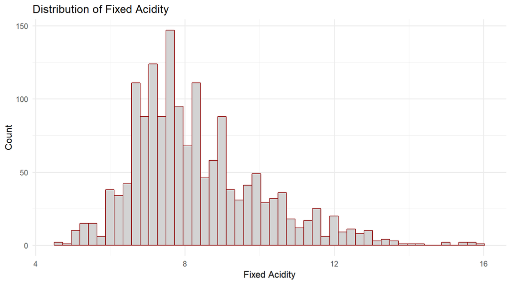

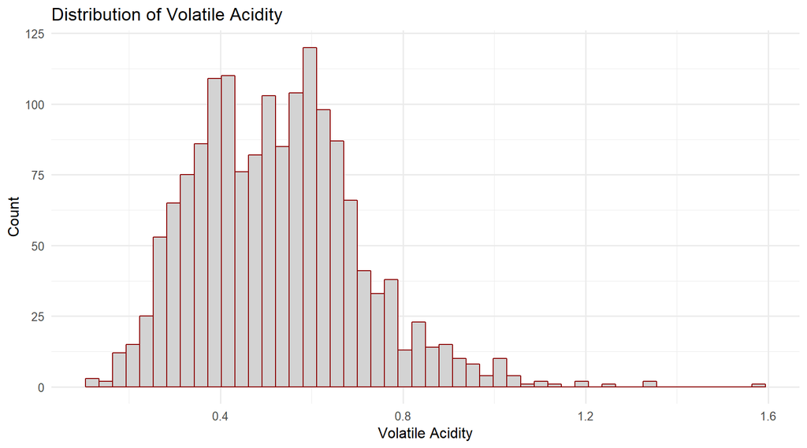

The mean of Volatile Acidity is 0.52 & median is also 0.52 but it’s not normal distribution it’s bimodal as the bar plot shows. There is outliers.

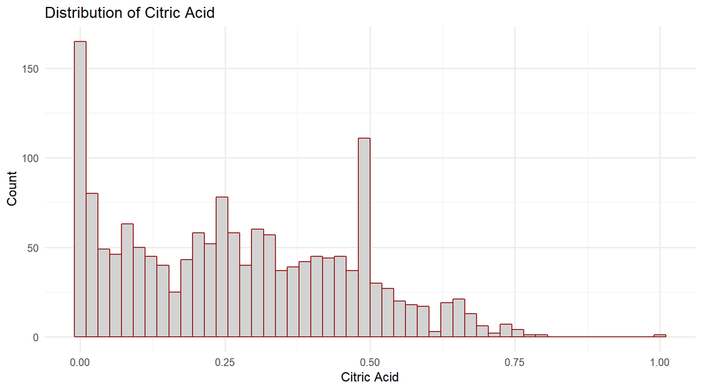

Critic Acid has a mean of 0.27 and median of 0.26 the distribution is low with two individual peaks and one outlier of high critic acidity This might indicate a poor data gathering or governance of the sensors.

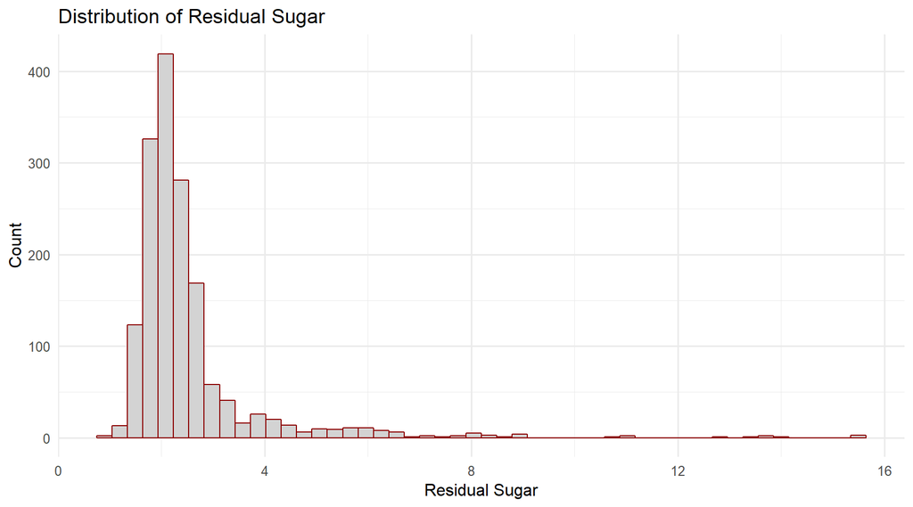

Residual Sugar has a mean of 2.54 and median of 2.2. Which justify the positively skewed graph at 2; outliers of high resifual sugar exists.

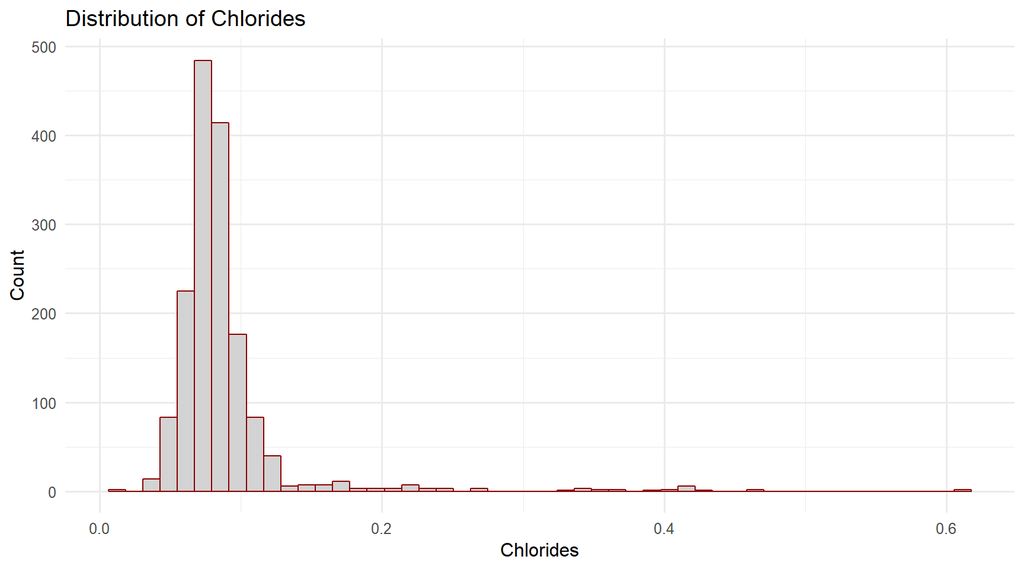

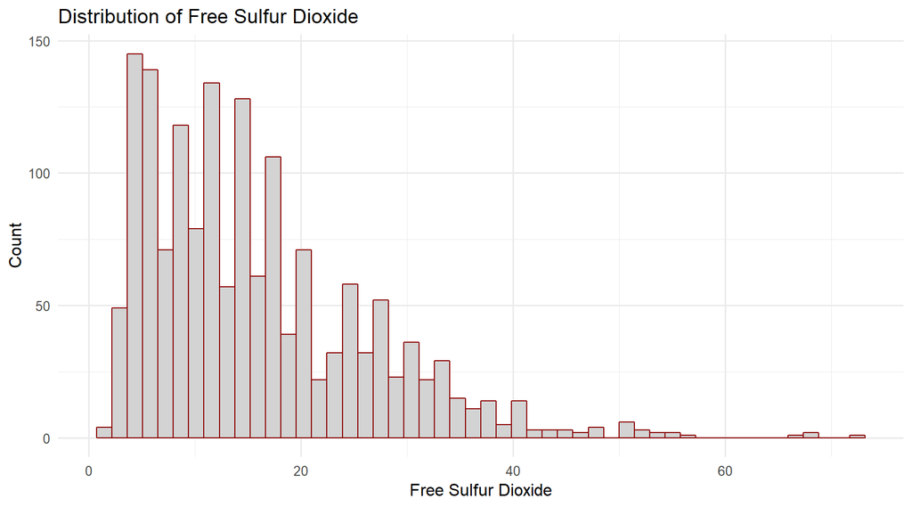

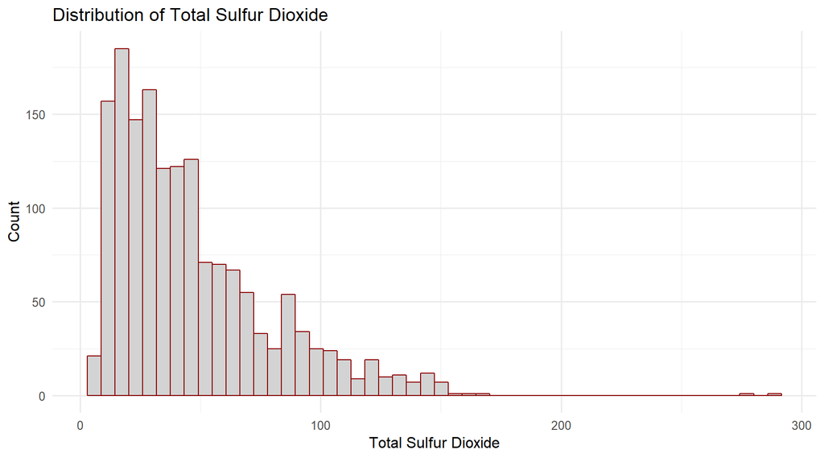

Total Sulfur Dioxide has a mean of 46 and median of 38. As this attribute and the previous one present the same chemical propery they share thame distribution

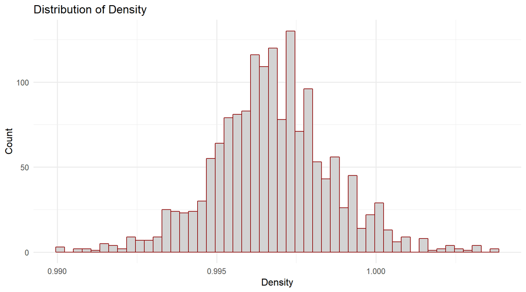

Density has a mean of 0.99 and median of 0.99 from mean & median and the plot we are firm it’s normal distribution

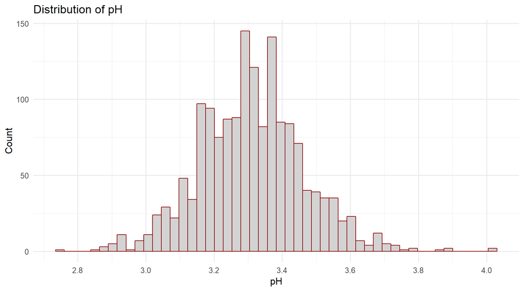

pH has a mean of 3.31 and median of 3.31 from mean & median and the plot we are firm it’s normal distribution

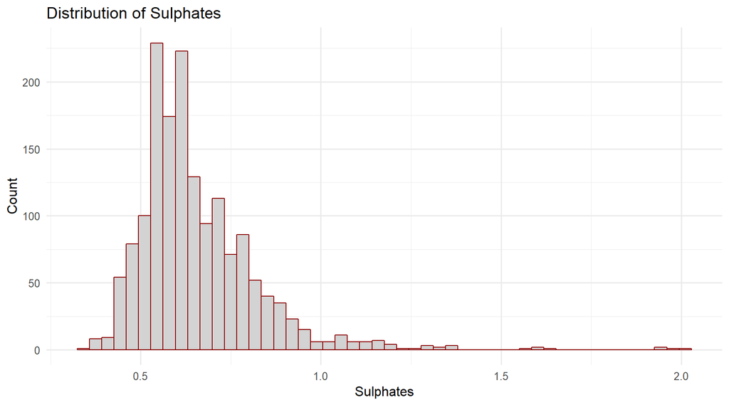

Sulphates has a mean of 0.65 and median of 0.62 positively skewed between 0.5-0.75 and has outliers.

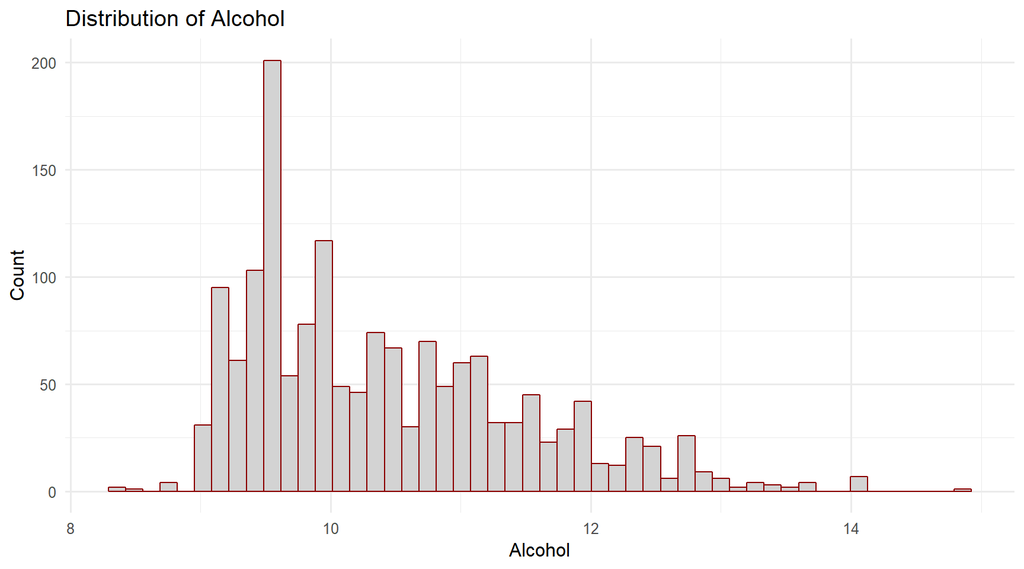

### What is the structure of your dataset?

print(“Red wine Quality data set has 1,599 rows and 11 attributes along with the target attribute it’s 12”) print(" The target attribute is quality and the only categoral attribute in the data set“) print(” The remaining attributes represent numerical chemical properties of the wine“)

### What is/are the main feature(s) of interest in your dataset?

Print(“my main interest is what features contributes more to the quality of wine”)

### What other features in the dataset do you think will help support your

## investigation into your feature(s) of interest?

print(“Most attributes have same distribution either right, normal or bimodal, I think all of them affects the quality”)

### Of the features you investigated, were there any unusual distributions? print(“Critic Acid”)

### Did you perform any operations on the data to tidy, adjust, or change the form  
###of the data? If so, why did you do this?

Bivariate Plots Section

```
## 'data.frame':    1599 obs. of  12 variables:
##  $ fixed.acidity       : num  7.4 7.8 7.8 11.2 7.4 7.4 7.9 7.3 7.8 7.5 ...
##  $ volatile.acidity    : num  0.7 0.88 0.76 0.28 0.7 0.66 0.6 0.65 0.58 0.5 ...
##  $ citric.acid         : num  0 0 0.04 0.56 0 0 0.06 0 0.02 0.36 ...
##  $ residual.sugar      : num  1.9 2.6 2.3 1.9 1.9 1.8 1.6 1.2 2 6.1 ...
##  $ chlorides           : num  0.076 0.098 0.092 0.075 0.076 0.075 0.069 0.065 0.073 0.071 ...
##  $ free.sulfur.dioxide : num  11 25 15 17 11 13 15 15 9 17 ...
##  $ total.sulfur.dioxide: num  34 67 54 60 34 40 59 21 18 102 ...
##  $ density             : num  0.998 0.997 0.997 0.998 0.998 ...
##  $ pH                  : num  3.51 3.2 3.26 3.16 3.51 3.51 3.3 3.39 3.36 3.35 ...
##  $ sulphates           : num  0.56 0.68 0.65 0.58 0.56 0.56 0.46 0.47 0.57 0.8 ...
##  $ alcohol             : num  9.4 9.8 9.8 9.8 9.4 9.4 9.4 10 9.5 10.5 ...
##  $ quality             : int  5 5 5 6 5 5 5 7 7 5 ...
```

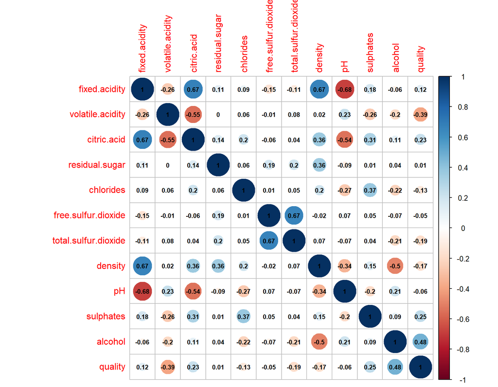

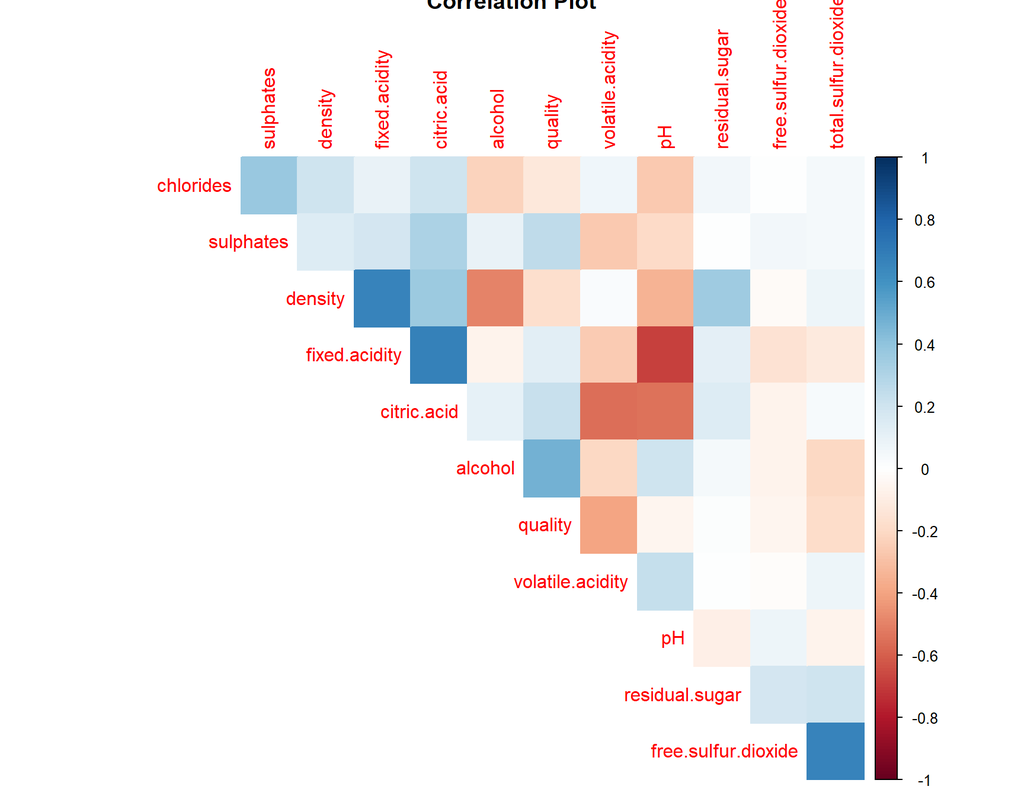

```
##
## ---------------------------------------------------------------------------
##           &nbsp;            fixed.acidity   volatile.acidity   citric.acid
## -------------------------- --------------- ------------------ -------------
##     **fixed.acidity**             1             -0.2561          0.6717
##
##    **volatile.acidity**        -0.2561             1             -0.5525
##
##      **citric.acid**           0.6717           -0.5525             1
##
##     **residual.sugar**         0.1148           0.001918         0.1436
##
##       **chlorides**            0.09371           0.0613          0.2038
##
##  **free.sulfur.dioxide**       -0.1538          -0.0105         -0.06098
##
##  **total.sulfur.dioxide**      -0.1132          0.07647          0.03553
##
##        **density**              0.668           0.02203          0.3649
##
##           **pH**               -0.683            0.2349          -0.5419
##
##       **sulphates**             0.183            -0.261          0.3128
##
##        **alcohol**            -0.06167          -0.2023          0.1099
##
##        **quality**             0.1241           -0.3906          0.2264
## ---------------------------------------------------------------------------
##
## Table: Table continues below
##
##
## -----------------------------------------------------------------------------
##           &nbsp;            residual.sugar   chlorides   free.sulfur.dioxide
## -------------------------- ---------------- ----------- ---------------------
##     **fixed.acidity**           0.1148        0.09371          -0.1538
##
##    **volatile.acidity**        0.001918       0.0613           -0.0105
##
##      **citric.acid**            0.1436        0.2038          -0.06098
```

[output cut: 66 more lines]

```
##
##  **free.sulfur.dioxide**     0.05166    -0.06941   -0.05066
##
##  **total.sulfur.dioxide**    0.04295    -0.2057    -0.1851
##
##        **density**           0.1485     -0.4962    -0.1749
##
##           **pH**             -0.1966     0.2056    -0.05773
##
##       **sulphates**             1       0.09359     0.2514
##
##        **alcohol**           0.09359       1        0.4762
##
##        **quality**           0.2514      0.4762       1
## ------------------------------------------------------------
```

From the correlation matrix, The highlights; Positive correlation between (alcohol & Quality)=0.476 Negative Correlation (Volatile Acidity & Quality)=-0.39

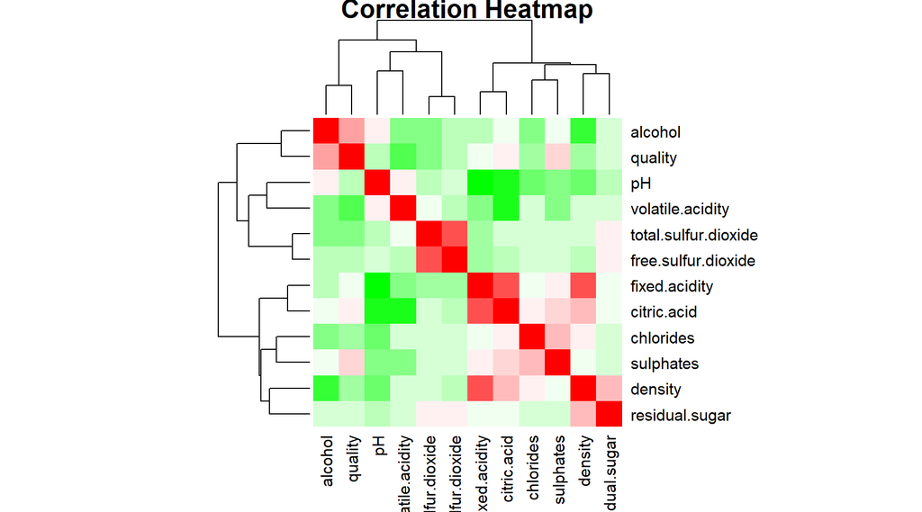

The heatmap supports the previos findings

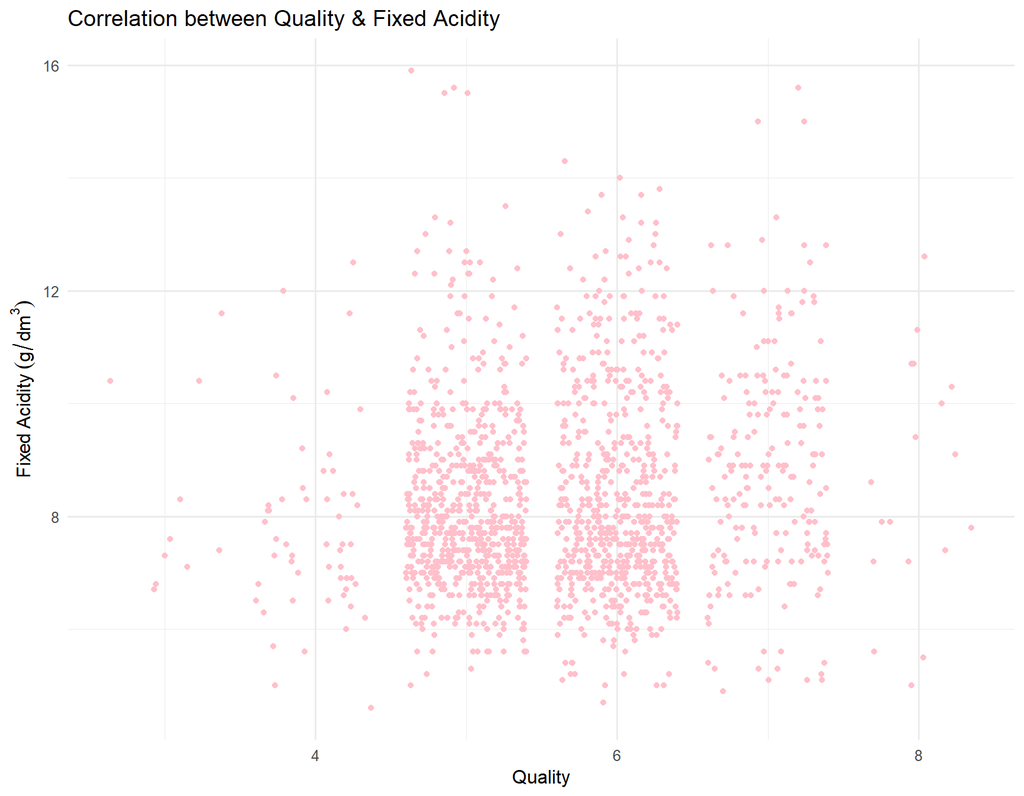

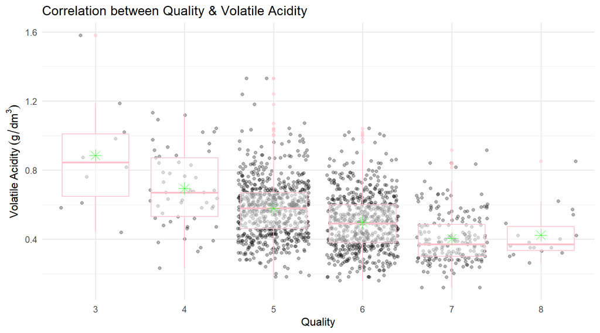

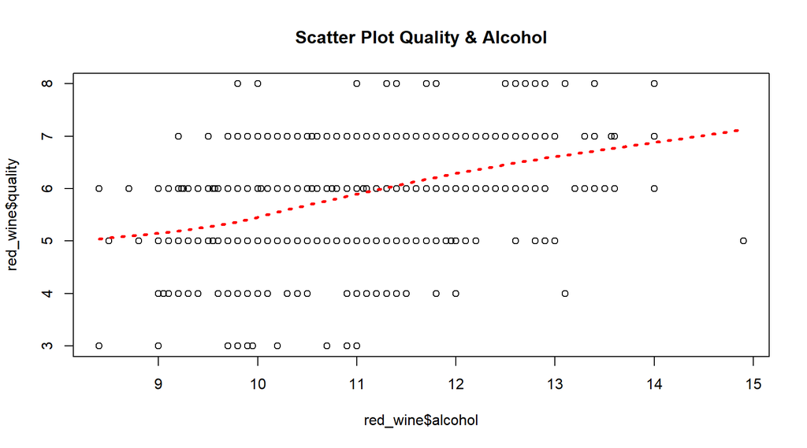

The slope of the scatter plot fits along 5-7 red wine quality.

# Bivariate Analysis

From the scatter plot we see the alcohol line is rising along. The low correlation between quality and volatile acidity -0.39

### Did you observe any interesting relationships between the other features From the correlation matrix I observed prominent high correlation between chemical properties

, (Volatile Acidity & critic acidity)=-0.55: They are both acids types that intersection wach other.

# Multivariate Plots Section

[figure not shown]

The plot consists of target feature (quality) with strong (Alcohol) and negative (volatile acidity) correlated features. The alcohol is immersed in the midde, the overall color of distance is pink which means low volatile acidity.

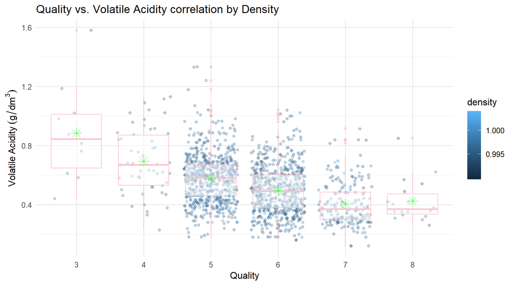

The box plot show the relationship between quality and volatile acidity. The relationship increases between 5-7 and the degree of strong relationship is shown by color shades of density which is dark, then it’s strongly correlated.

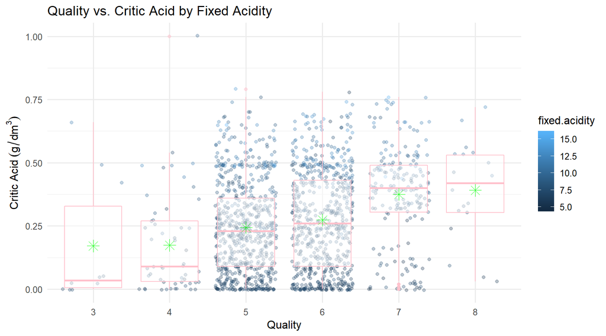

The boxes of quality in 6 and 7 have strong correlation with fixed acidity. The critic acid of correlation points are 0.12-0.42.

# Multivariate Analysis

```
##
## Call:
## lm(formula = as.numeric(quality) ~ alcohol + volatile.acidity +
##     sulphates + citric.acid + fixed.acidity + pH, data = training_data)
##
## Residuals:
##      Min       1Q   Median       3Q      Max
## -2.69045 -0.38863 -0.06562  0.45943  1.97867
##
## Coefficients:
##                  Estimate Std. Error t value Pr(>|t|)
## (Intercept)       3.47843    0.64885   5.361 9.83e-08 ***
## alcohol           0.32123    0.01824  17.609  < 2e-16 ***
## volatile.acidity -1.34525    0.12543 -10.725  < 2e-16 ***
## sulphates         0.68824    0.11484   5.993 2.68e-09 ***
## citric.acid      -0.58474    0.15391  -3.799 0.000152 ***
## fixed.acidity     0.03619    0.01667   2.171 0.030122 *
## pH               -0.32511    0.17224  -1.888 0.059310 .
## ---
## Signif. codes:  0 '***' 0.001 '**' 0.01 '*' 0.05 '.' 0.1 ' ' 1
##
## Residual standard error: 0.658 on 1272 degrees of freedom
## Multiple R-squared:  0.3385, Adjusted R-squared:  0.3354
## F-statistic: 108.5 on 6 and 1272 DF,  p-value: < 2.2e-16
```

### Were there any interesting or surprising interactions between features?

The three acidity features, Volatile acidity, critic acidity and fixed acidity. Fixed acidity and volatile acidity has negative correlation. but Fixed acidity and critic acid has positive correlation.

### OPTIONAL: Did you create any models with your dataset?

# Final Plots and Summary

Plot One

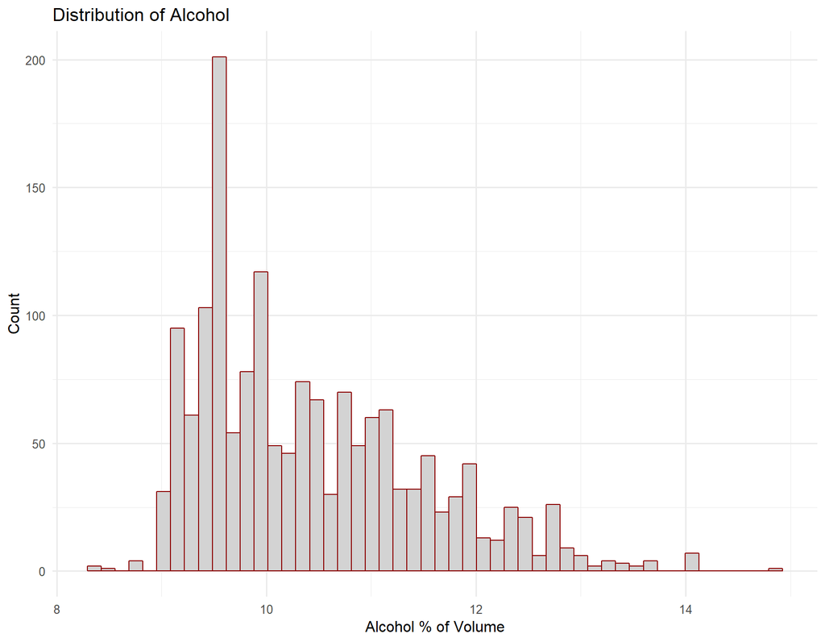

### Description One

Alcohol is the major affective feature in red wine quality. It has Right skeweddistribution. Alcohol has a mean of 10.42 and median of 10.20, outliers exists.

Plot Two

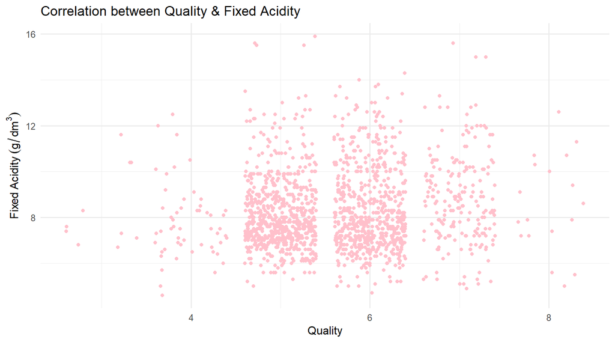

### Description Two

The quality intensifies at 5 and 6 with fixed acidity between 6-10

Plot Three

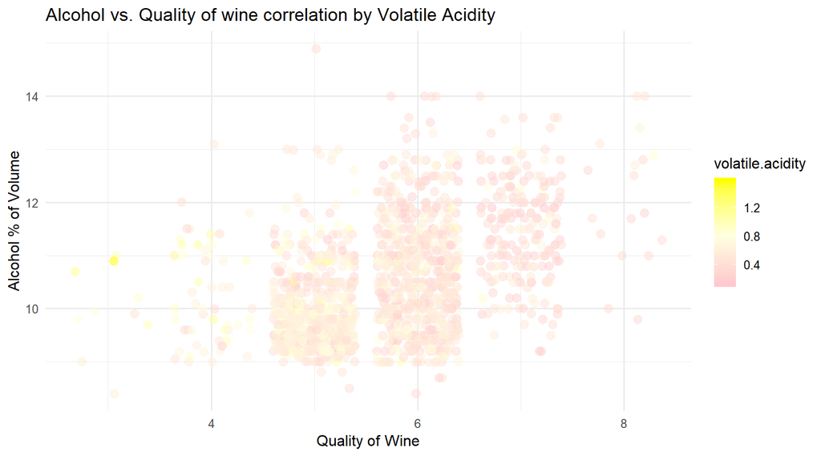

### Description Three

Quality of wine increases mostly between 5-7 with alcohol amount of 9 to 13 While in both condition the volatile acidity is mainly 0.4 ——

# Reflection

The major contribution to quality of the features is alcohol, which is predictable and the analysis is right. Also, Sulfates has a small positive contribution. Its normally used to prevent rotting. A down side contribution to quality is Volatile acidity , Volatile acidity affects to the acidic taste. I struggled with lack of data to statistics. also with data accuracy and data collection. Some were not reasonable. Most correlation went as expected and the overall analysis is expected.

Positive Correlation: 1. Density with Fixed Acidity. Which is reasonable 2. Quality and Alcohol. which is also reasonable 3. Fixed acidity and critic acid.

I personally didn’t like R, it’s exhausting. As a data analyst I usually use python, matlab at worse. It’s good that I have a basic knowledge about the great language but I don’t prefer it as my top skill.

For Future work, get a better data obviously and more features that describe the wine such where it was made, how long has it been stored and other ingredients not mentioned in the dataset.